# TP 2: Valores Shap

Damian Fontenla / Santiago Chas

4 de Diciembre de 2022

## Análisis y Evaluación de Valores Shap sobre un XGBoost

```r
rm( list=ls() )  #remove all objects
gc()
```

```
          used (Mb) gc trigger (Mb) limit (Mb) max used (Mb)
Ncells  539293 28.9    1206217 64.5         NA   669240 35.8
Vcells 1008776  7.7    8388608 64.0      65536  1926000 14.7
```

```r
 library(dplyr)

library(corrr)
library(ggplot2)
library(tidyverse)
library(tidymodels)
library(rsample)
library(gridExtra)
library(knitr)
library(kableExtra)
library(GGally)
#install.packages("shapr")
library(xgboost)
library(shapr)
```

### Dataset

Importamos el dataset sacado de kaggle, con información estadística de partidos disputados en el mundial 2018

```r
fifa <- read.csv("/Users/dfontenla/Maestria/2022C2/EEA/damirepo/shapley_values/eea_tp2/R/FIFA 2018 Statistics - NOTNA - NTARGET + categorical prediction.csv", encoding = "UTF-8")
```

Analizamos el dataset, previamente realizamos un procesamiento manual de imputar valores nulos.

```r
fifa %>% glimpse()
```

```
Rows: 128
Columns: 28
$ Date                   <chr> "14-06-2018", "14-06-2018", "15-06-2018", "15-0…
$ Team                   <chr> "Russia", "Saudi Arabia", "Egypt", "Uruguay", "…
$ Opponent               <chr> "Saudi Arabia", "Russia", "Uruguay", "Egypt", "…
$ Goal.Scored            <int> 5, 0, 0, 1, 0, 1, 3, 3, 2, 1, 1, 1, 0, 1, 2, 0,…
$ Ball.Possession..      <int> 40, 60, 43, 57, 64, 36, 39, 61, 51, 49, 72, 28,…
$ Attempts               <int> 13, 6, 8, 14, 13, 8, 8, 12, 12, 4, 26, 9, 18, 1…
$ On.Target              <int> 7, 0, 3, 4, 3, 2, 3, 5, 5, 1, 7, 3, 6, 3, 2, 2,…
$ Off.Target             <int> 3, 3, 3, 6, 6, 5, 2, 5, 4, 2, 9, 5, 7, 5, 7, 5,…
$ Blocked                <int> 3, 3, 2, 4, 4, 1, 3, 2, 3, 1, 10, 1, 5, 2, 2, 7…
$ Corners                <int> 6, 2, 0, 5, 5, 2, 4, 5, 5, 1, 10, 2, 3, 7, 6, 5…
$ Offsides               <int> 3, 1, 1, 1, 0, 0, 1, 3, 0, 0, 0, 0, 5, 3, 2, 1,…
$ Free.Kicks             <int> 11, 25, 7, 13, 14, 22, 13, 13, 19, 16, 15, 10, …
$ Saves                  <int> 0, 2, 3, 3, 2, 2, 2, 0, 1, 4, 2, 7, 2, 6, 2, 1,…
$ Pass.Accuracy..        <int> 78, 86, 78, 86, 86, 86, 87, 93, 87, 85, 92, 67,…
$ Passes                 <int> 306, 511, 395, 589, 433, 194, 366, 727, 484, 39…
$ Distance.Covered..Kms. <int> 118, 105, 112, 111, 101, 100, 102, 103, 103, 11…
$ Fouls.Committed        <int> 22, 10, 12, 6, 22, 14, 12, 10, 16, 19, 10, 15, …
$ Yellow.Card            <int> 0, 0, 2, 0, 1, 3, 1, 1, 1, 3, 0, 0, 1, 2, 2, 1,…
$ Yellow...Red           <int> 0, 0, 0, 0, 0, 0, 0, 0, 0, 0, 0, 0, 0, 0, 0, 0,…
$ Red                    <int> 0, 0, 0, 0, 0, 0, 0, 0, 0, 0, 0, 0, 0, 0, 0, 0,…
$ Man.of.the.Match       <int> 1, 0, 0, 1, 0, 1, 0, 1, 1, 0, 0, 1, 0, 1, 1, 0,…
$ X1st.Goal              <int> 12, 0, 0, 89, 0, 90, 4, 24, 58, 62, 19, 23, 0, …
$ Round                  <chr> "Group Stage", "Group Stage", "Group Stage", "G…
$ PSO                    <int> 0, 0, 0, 0, 0, 0, 0, 0, 0, 0, 0, 0, 0, 0, 0, 0,…
$ Goals.in.PSO           <int> 0, 0, 0, 0, 0, 0, 0, 0, 0, 0, 0, 0, 0, 0, 0, 0,…
$ Own.goals              <int> 0, 0, 0, 0, 1, 0, 0, 0, 0, 1, 0, 0, 0, 0, 0, 1,…
$ Own.goal.Time          <int> 0, 0, 0, 0, 90, 0, 0, 0, 0, 81, 0, 0, 0, 0, 0, …
$ MOM_CAT                <chr> "YES", "NO", "NO", "YES", "NO", "YES", "NO", "Y…
```

Rows: 128 Columns: 28

Ejecutamos ggpairs para analizar la correlación de los datos discriminandolos por la predicción que queremos hacer

[figure not shown]

```r
numeric_var <- c("Goal.Scored", "Ball.Possession..", "Attempts", "On.Target", "Blocked", "Off.Target", "Corners", "Offsides", "Free.Kicks", "Saves",
"Passes", "Pass.Accuracy..","Distance.Covered..Kms.","Fouls.Committed","Yellow.Card","Yellow...Red","Red", "MOM_CAT")

fifa_numeric = fifa %>% dplyr::select(numeric_var)

fifa_numeric %>% ggpairs(aes(color=MOM_CAT)) +
  theme_bw() +
  theme(axis.text.x = element_text(angle=45, vjust=0.5), legend.position = "bottom")
```

Observamos numéricamente como se correlacionan los datos

```r
fifa_numeric %>%
 correlate() %>% # convierte la matriz de corr en dataframe
  shave() %>% # solo muestra información debajo de la diagonal principal
  fashion() # acomoda los datos en forma tidy (por ej. redondeo de decimales)
```

| term | Goal.Scored | Ball.Possession.. | Attempts | On.Target | Blocked | Off.Target | Corners | Offsides | Free.Kicks | Saves | Passes | Pass.Accuracy.. | Distance.Covered..Kms. | Fouls.Committed | Yellow.Card | Yellow...Red | Red |
| --- | --- | --- | --- | --- | --- | --- | --- | --- | --- | --- | --- | --- | --- | --- | --- | --- | --- |
| Goal.Scored |  |  |  |  |  |  |  |  |  |  |  |  |  |  |  |  |  |
| Ball.Possession.. | .03 |  |  |  |  |  |  |  |  |  |  |  |  |  |  |  |  |
| Attempts | .14 | .54 |  |  |  |  |  |  |  |  |  |  |  |  |  |  |  |
| On.Target | .46 | .30 | .73 |  |  |  |  |  |  |  |  |  |  |  |  |  |  |
| Blocked | -.09 | .52 | .75 | .33 |  |  |  |  |  |  |  |  |  |  |  |  |  |
| Off.Target | -.02 | .36 | .72 | .32 | .30 |  |  |  |  |  |  |  |  |  |  |  |  |
| Corners | .04 | .54 | .69 | .41 | .64 | .44 |  |  |  |  |  |  |  |  |  |  |  |
| Offsides | .05 | .06 | -.02 | .07 | -.00 | -.10 | -.03 |  |  |  |  |  |  |  |  |  |  |
| Free.Kicks | .05 | .27 | .14 | .09 | .09 | .14 | .09 | .09 |  |  |  |  |  |  |  |  |  |
| Saves | -.12 | -.29 | -.27 | -.32 | -.14 | -.13 | -.23 | .01 | -.23 |  |  |  |  |  |  |  |  |

[output cut: 7 more lines]

Lo graficamos para tener las relaciones de una forma mas descriptiva

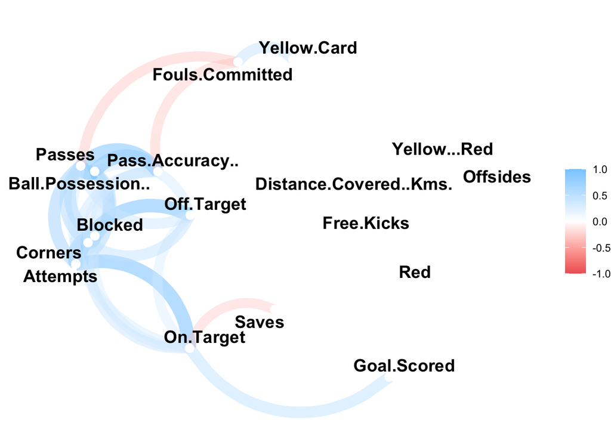

```r
fifa_numeric %>%
 correlate() %>%
  network_plot(min_cor = 0.3)
```

## Predicción

Seleccionamos los valores de nuestro dataset que utilizaremos en el modelo a generar, y separamos datos de train y test para entrenar nuestro modelo y posteriormente ejecutar la predicción de los datos separados en testing

```r
y_var <- "Man.of.the.Match"
x_var <- c("Goal.Scored", "Ball.Possession..", "Attempts", "On.Target", "Blocked", "Off.Target", "Corners", "Offsides", "Free.Kicks", "Saves",
"Passes", "Pass.Accuracy..","Fouls.Committed")

x_train <- as.matrix(fifa[-1:-10, x_var])
y_train <- fifa[-1:-10, y_var]
x_test <- as.matrix(fifa[1:10, x_var])
```

Para predecir utilizaremos xgboost, la idea es poder utilizar un modelo poco interpretable, no tenemos forma de poder saber como se desarma una predicción, solo según la importancia de cada feature, para llegar al valor obtenido.

```r
# Fitting a basic xgboost model to the training data
model <- xgboost(
  data = x_train,
  label = y_train,
  nround = 20,
  verbose = FALSE
)
```

## Implementación Shap

Utilizamos la libreria shap de R para poder explicar una predicción realizada por xgboost, tenemos el metodo shapr, que nos arroja el objeto explainer el cual utilizaremos para poder interpretar la prediccion

```r
# Prepare the data for explanation
explainer <- shapr(x_train, model)
```

```
#> The specified model provides feature classes that are NA. The classes of data are taken as the truth.
```

```r
# Specifying the phi_0, i.e. the expected prediction without any features
p <- mean(y_train)

str(x_test)
```

```
 int [1:10, 1:13] 5 0 0 1 0 1 3 3 2 1 ...
 - attr(*, "dimnames")=List of 2
  ..$ : chr [1:10] "1" "2" "3" "4" ...
  ..$ : chr [1:13] "Goal.Scored" "Ball.Possession.." "Attempts" "On.Target" ...
```

Aplicamos la función explain para interpretar nuestro dataset de test que separamos del modelo

```r
# Computing the actual Shapley values with kernelSHAP accounting for feature dependence using
# the empirical (conditional) distribution approach with bandwidth parameter sigma = 0.1 (default)
explanation <- explain(
  x_test,
  approach = "empirical",
  explainer = explainer,
  prediction_zero = p
)
```

Desplegamos los resultados que nos arroja la explicación de Shap para la predicción

```r
# Printing the Shapley values for the test data.
# For more information about the interpretation of the values in the table, see ?shapr::explain.
print(explanation$dt)
```

```
    none Goal.Scored Ball.Possession..     Attempts   On.Target       Blocked
 1:  0.5  0.36130964      -0.105958231  0.001102721  0.10212181  0.0264766266
 2:  0.5 -0.34390076       0.087498347 -0.073005266 -0.13748688 -0.0277615538
 3:  0.5 -0.28875647      -0.013615317 -0.020468188 -0.01644989 -0.0007678223
 4:  0.5  0.11106621      -0.007014075  0.021355768  0.07051020 -0.0163623250
 5:  0.5 -0.51716206       0.050099312  0.022424305 -0.01101398  0.0090470536
 6:  0.5 -0.01656068      -0.090681849 -0.055857364 -0.04255266 -0.0108452876
 7:  0.5  0.25978817       0.010685848 -0.067812713 -0.00734803 -0.0242678903
 8:  0.5  0.28357879      -0.001836864  0.046093122 -0.03514306  0.0311358455
 9:  0.5  0.26977113      -0.003550776  0.016958369  0.02274932 -0.0020705733
10:  0.5  0.06713703       0.051027507  0.022059921 -0.09316309  0.0148947733
      Off.Target     Corners    Offsides  Free.Kicks         Saves       Passes
 1: -0.016983851 -0.02456193  0.07497131 -0.03574529 -0.0005135169 -0.020320817
 2:  0.001175202  0.02511654  0.14040429 -0.01464530 -0.0014694975 -0.007012509
 3: -0.019168660 -0.03248609  0.06124163 -0.11097347  0.0335194048  0.012887739
```

[output cut: 18 more lines]

[output not shown]

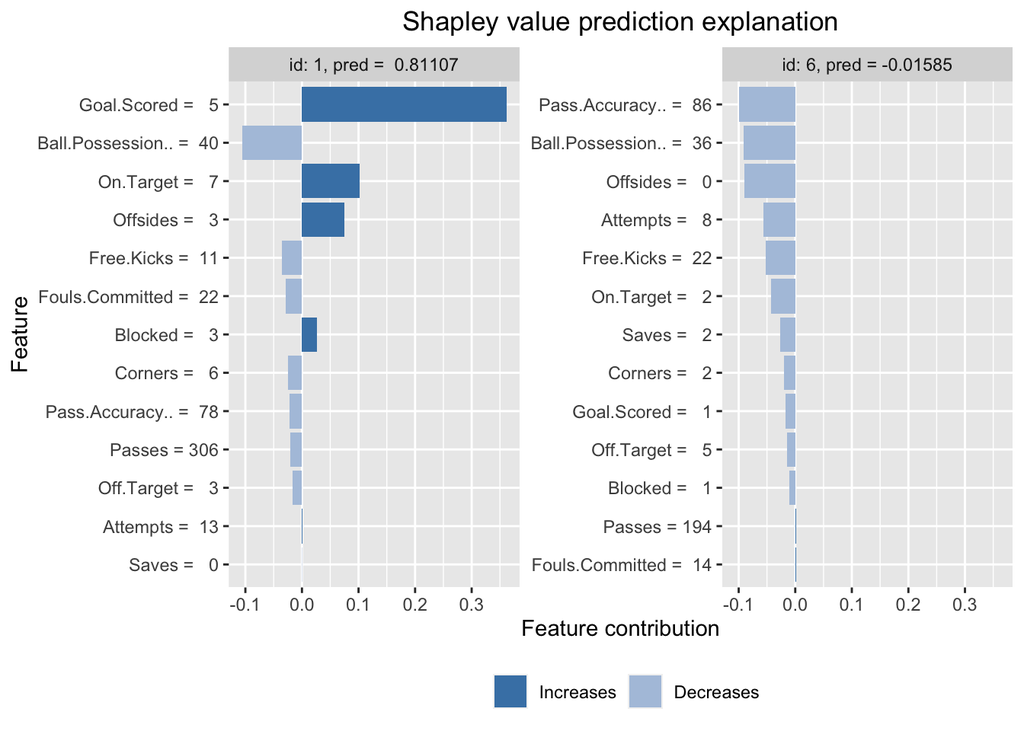

```r
# Plot the resulting explanations for observations 1 and 6
plot(explanation, plot_phi0 = FALSE, index_x_test = c(1, 6))
```

Observamos como valores tanto positivos como negativos, el signo nos brinda tambien interpretabilidad de como ese feature para la predicción buscada esta aportando o restando a nuestro resultado final

Graficamos como se interpreta la predicción de nuestro modelo segun el metodo shap en nuestro dataset de test

```r
print(explanation$dt)
```

```
    none Goal.Scored Ball.Possession..     Attempts   On.Target       Blocked
 1:  0.5  0.36130964      -0.105958231  0.001102721  0.10212181  0.0264766266
 2:  0.5 -0.34390076       0.087498347 -0.073005266 -0.13748688 -0.0277615538
 3:  0.5 -0.28875647      -0.013615317 -0.020468188 -0.01644989 -0.0007678223
 4:  0.5  0.11106621      -0.007014075  0.021355768  0.07051020 -0.0163623250
 5:  0.5 -0.51716206       0.050099312  0.022424305 -0.01101398  0.0090470536
 6:  0.5 -0.01656068      -0.090681849 -0.055857364 -0.04255266 -0.0108452876
 7:  0.5  0.25978817       0.010685848 -0.067812713 -0.00734803 -0.0242678903
 8:  0.5  0.28357879      -0.001836864  0.046093122 -0.03514306  0.0311358455
 9:  0.5  0.26977113      -0.003550776  0.016958369  0.02274932 -0.0020705733
10:  0.5  0.06713703       0.051027507  0.022059921 -0.09316309  0.0148947733
      Off.Target     Corners    Offsides  Free.Kicks         Saves       Passes
 1: -0.016983851 -0.02456193  0.07497131 -0.03574529 -0.0005135169 -0.020320817
 2:  0.001175202  0.02511654  0.14040429 -0.01464530 -0.0014694975 -0.007012509
 3: -0.019168660 -0.03248609  0.06124163 -0.11097347  0.0335194048  0.012887739
```

[output cut: 18 more lines]

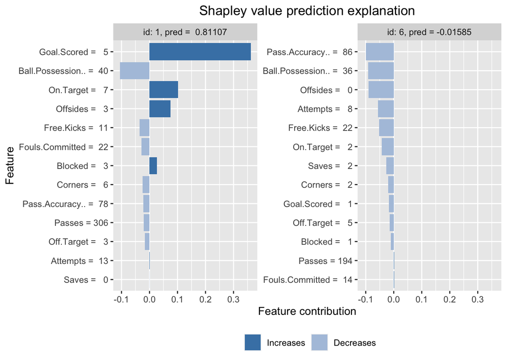

```r
plot(explanation, plot_phi0 = FALSE, index_x_test = c(1, 6))
```

```r
x_test
```

```
   Goal.Scored Ball.Possession.. Attempts On.Target Blocked Off.Target Corners
1            5                40       13         7       3          3       6
2            0                60        6         0       3          3       2
3            0                43        8         3       2          3       0
4            1                57       14         4       4          6       5
5            0                64       13         3       4          6       5
6            1                36        8         2       1          5       2
7            3                39        8         3       3          2       4
8            3                61       12         5       2          5       5
9            2                51       12         5       3          4       5
10           1                49        4         1       1          2       1
   Offsides Free.Kicks Saves Passes Pass.Accuracy.. Fouls.Committed
1         3         11     0    306              78              22
2         1         25     2    511              86              10
3         1          7     3    395              78              12
4         1         13     3    589              86               6
5         0         14     2    433              86              22
6         0         22     2    194              86              14
7         1         13     2    366              87              12
8         3         13     0    727              93              10
9         0         19     1    484              87              16
10        0         16     4    390              85              19
```

```r
y_test <- fifa[1:10, y_var]
y_test
```

```
 [1] 1 0 0 1 0 1 0 1 1 0
```

[figure not shown]

```r
plot(explanation, plot_phi0 = FALSE)
```